# Heavy_Drinking_1

Min-Yao

9/26/2021

```r
library(tidyverse)
library(keras)
use_condaenv("r-reticulate")
```

# Bar Crawl: Detecting Heavy Drinking Data Set

Data Set Information:

Relevant Information: All data is fully anonymized.

Data was originally collected from 19 participants, but the TAC readings of 6 participants were deemed unusable by SCRAM [1]. The data included is from the remaining 13 participants.

Accelerometer data was collected from smartphones at a sampling rate of 40Hz (file: all_accelerometer_data_pids_13.csv). The file contains 5 columns: a timestamp, a participant ID, and a sample from each axis of the accelerometer. Data was collected from a mix of 11 iPhones and 2 Android phones as noted in phone_types.csv. TAC data was collected using SCRAM [2] ankle bracelets and was collected at 30 minute intervals. The raw TAC readings are in the raw_tac directory. TAC readings which are more readily usable for processing are in clean_tac directory and have two columns: a timestamp and TAC reading. The cleaned TAC readings: (1) were processed with a zero-phase low-pass filter to smooth noise without shifting phase; (2) were shifted backwards by 45 minutes so the labels more closely match the true intoxication of the participant (since alcohol takes about 45 minutes to exit through the skin.) Please see the above referenced study for more details on how the data was processed ([Web Link]).

1 - [Web Link] 2 - J. Robert Zettl. The determination of blood alcohol concentration by transdermal measurement. [Web Link], 2002.

Number of Instances: Accelerometer readings: 14,057,567 TAC readings: 715 Participants: 13

Number of Attributes: - Time series: 3 axes of accelerometer data (columns x, y, z in all_accelerometer_data_pids_13.csv) - Static: 1 phone-type feature (in phone_types.csv) - Target: 1 time series of TAC for each of the 13 participants (in clean_tac directory).

For Each Attribute: (Main) all_accelerometer_data_pids_13.csv: time: integer, unix timestamp, milliseconds pid: symbolic, 13 categories listed in pids.txt x: continuous, time-series y: continuous, time-series z: continuous, time-series clean_tac/*.csv: timestamp: integer, unix timestamp, seconds TAC_Reading: continuous, time-series phone_type.csv: pid: symbolic, 13 categories listed in pids.txt phonetype: symbolic, 2 categories (iPhone, Android)

(Other) raw/*.xlsx: TAC Level: continuous, time-series IR Voltage: continuous, time-series Temperature: continuous, time-series Time: datetime Date: datetime

Missing Attribute Values: None

Target Distribution: TAC is measured in g/dl where 0.08 is the legal limit for intoxication while driving Mean TAC: 0.065 +/- 0.182 Max TAC: 0.443 TAC Inner Quartiles: 0.002, 0.029, 0.092 Mean Time-to-last-drink: 16.1 +/- 6.9 hrs

## Get the data

### acceleromator

```r
acc <- read_csv("all_accelerometer_data_pids_13.csv")
head(acc)
```

```
## # A tibble: 6 x 5
##            time pid          x       y       z
##           <dbl> <chr>    <dbl>   <dbl>   <dbl>
## 1             0 JB3156  0       0       0
## 2             0 CC6740  0       0       0
## 3 1493733882409 SA0297  0.0758  0.0273 -0.0102
## 4 1493733882455 SA0297 -0.0359  0.0794  0.0037
## 5 1493733882500 SA0297 -0.243  -0.0861 -0.0163
## 6 1493733883945 SA0297 -0.289   0.0514 -0.0145
```

```r
str(acc)
```

```
## spec_tbl_df [14,057,567 x 5] (S3: spec_tbl_df/tbl_df/tbl/data.frame)
##  $ time: num [1:14057567] 0.00 0.00 1.49e+12 1.49e+12 1.49e+12 ...
##  $ pid : chr [1:14057567] "JB3156" "CC6740" "SA0297" "SA0297" ...
##  $ x   : num [1:14057567] 0 0 0.0758 -0.0359 -0.2427 ...
##  $ y   : num [1:14057567] 0 0 0.0273 0.0794 -0.0861 0.0514 -0.0184 -0.0001 -0.0028 -0.041 ...
##  $ z   : num [1:14057567] 0 0 -0.0102 0.0037 -0.0163 -0.0145 -0.0105 0.0017 -0.0094 -0.0109 ...
##  - attr(*, "spec")=
##   .. cols(
##   ..   time = col_double(),
##   ..   pid = col_character(),
##   ..   x = col_double(),
##   ..   y = col_double(),
##   ..   z = col_double()
##   .. )
##  - attr(*, "problems")=<externalptr>
```

```r
acc_a <- acc %>% mutate(time_30m = as.integer(round(time/1000/60/30)))
acc_a
```

```
## # A tibble: 14,057,567 x 6
##             time pid          x       y       z time_30m
##            <dbl> <chr>    <dbl>   <dbl>   <dbl>    <int>
##  1             0 JB3156  0       0       0             0
##  2             0 CC6740  0       0       0             0
##  3 1493733882409 SA0297  0.0758  0.0273 -0.0102   829852
##  4 1493733882455 SA0297 -0.0359  0.0794  0.0037   829852
##  5 1493733882500 SA0297 -0.243  -0.0861 -0.0163   829852
##  6 1493733883945 SA0297 -0.289   0.0514 -0.0145   829852
##  7 1493733883953 SA0297 -0.0413 -0.0184 -0.0105   829852
##  8 1493733883957 SA0297 -0.0413 -0.0001  0.0017   829852
##  9 1493733883963 SA0297 -0.0286 -0.0028 -0.0094   829852
## 10 1493733883974 SA0297 -0.0543 -0.041  -0.0109   829852
## # ... with 14,057,557 more rows
```

```r
str(acc_a)
```

```
## spec_tbl_df [14,057,567 x 6] (S3: spec_tbl_df/tbl_df/tbl/data.frame)
##  $ time    : num [1:14057567] 0.00 0.00 1.49e+12 1.49e+12 1.49e+12 ...
##  $ pid     : chr [1:14057567] "JB3156" "CC6740" "SA0297" "SA0297" ...
##  $ x       : num [1:14057567] 0 0 0.0758 -0.0359 -0.2427 ...
##  $ y       : num [1:14057567] 0 0 0.0273 0.0794 -0.0861 0.0514 -0.0184 -0.0001 -0.0028 -0.041 ...
##  $ z       : num [1:14057567] 0 0 -0.0102 0.0037 -0.0163 -0.0145 -0.0105 0.0017 -0.0094 -0.0109 ...
##  $ time_30m: int [1:14057567] 0 0 829852 829852 829852 829852 829852 829852 829852 829852 ...
##  - attr(*, "spec")=
##   .. cols(
##   ..   time = col_double(),
##   ..   pid = col_character(),
##   ..   x = col_double(),
##   ..   y = col_double(),
##   ..   z = col_double()
##   .. )
##  - attr(*, "problems")=<externalptr>
```

### TAC

```r
data_files <- list.files("clean_tac/",full.names = TRUE)
data_list <- setNames(lapply(data_files, read_csv), data_files)
tac_all <- bind_rows(data_list,.id = "id")
tac_all
```

```
## # A tibble: 715 x 3
##    id                              timestamp TAC_Reading
##    <chr>                               <dbl>       <dbl>
##  1 clean_tac/BK7610_clean_TAC.csv 1493718714   -0.000482
##  2 clean_tac/BK7610_clean_TAC.csv 1493720697    0.00157
##  3 clean_tac/BK7610_clean_TAC.csv 1493721027    0.00214
##  4 clean_tac/BK7610_clean_TAC.csv 1493721357    0.000877
##  5 clean_tac/BK7610_clean_TAC.csv 1493721686   -0.00115
##  6 clean_tac/BK7610_clean_TAC.csv 1493722016   -0.00216
##  7 clean_tac/BK7610_clean_TAC.csv 1493722345   -0.00103
##  8 clean_tac/BK7610_clean_TAC.csv 1493722674    0.00181
##  9 clean_tac/BK7610_clean_TAC.csv 1493723003    0.00454
## 10 clean_tac/BK7610_clean_TAC.csv 1493724832    0.00518
## # ... with 705 more rows
```

```r
tac_all %>% mutate(realtime=as.POSIXct(timestamp, origin="1970-01-01"))
```

```
## # A tibble: 715 x 4
##    id                              timestamp TAC_Reading realtime
##    <chr>                               <dbl>       <dbl> <dttm>
##  1 clean_tac/BK7610_clean_TAC.csv 1493718714   -0.000482 2017-05-02 10:51:54
##  2 clean_tac/BK7610_clean_TAC.csv 1493720697    0.00157  2017-05-02 11:24:57
##  3 clean_tac/BK7610_clean_TAC.csv 1493721027    0.00214  2017-05-02 11:30:27
##  4 clean_tac/BK7610_clean_TAC.csv 1493721357    0.000877 2017-05-02 11:35:57
##  5 clean_tac/BK7610_clean_TAC.csv 1493721686   -0.00115  2017-05-02 11:41:26
##  6 clean_tac/BK7610_clean_TAC.csv 1493722016   -0.00216  2017-05-02 11:46:56
##  7 clean_tac/BK7610_clean_TAC.csv 1493722345   -0.00103  2017-05-02 11:52:25
##  8 clean_tac/BK7610_clean_TAC.csv 1493722674    0.00181  2017-05-02 11:57:54
##  9 clean_tac/BK7610_clean_TAC.csv 1493723003    0.00454  2017-05-02 12:03:23
## 10 clean_tac/BK7610_clean_TAC.csv 1493724832    0.00518  2017-05-02 12:33:52
## # ... with 705 more rows
```

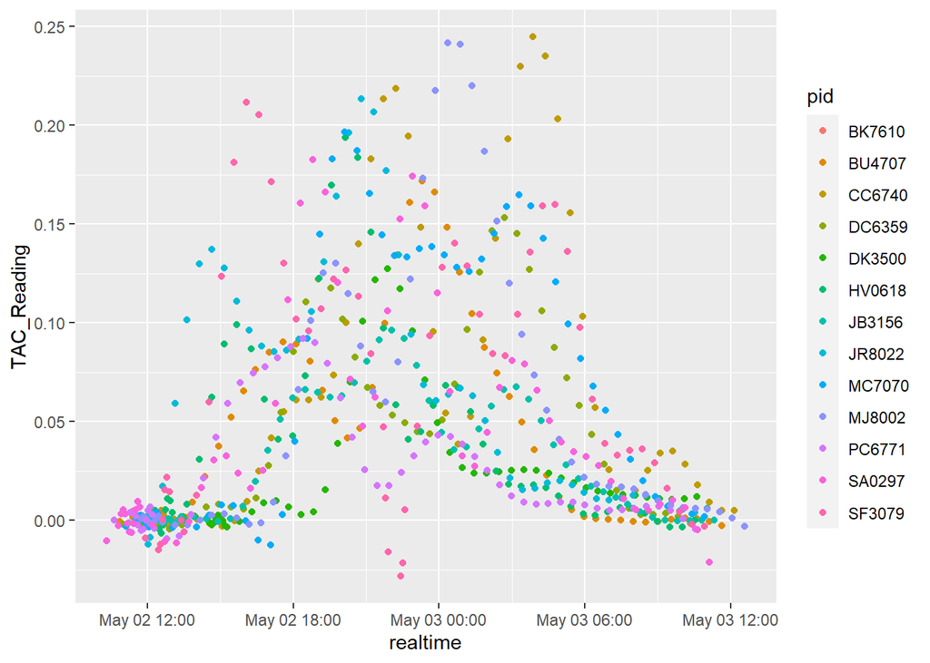

```r
tac_all %>% mutate(realtime=as.POSIXct(timestamp, origin="1970-01-01")) %>%
  mutate(pid=str_remove(id, "clean_tac/")) %>%
  mutate(pid=str_remove(pid, "_clean_TAC.csv")) %>%
  ggplot(aes(x=realtime, y=TAC_Reading, color=pid)) +
  geom_point()
```

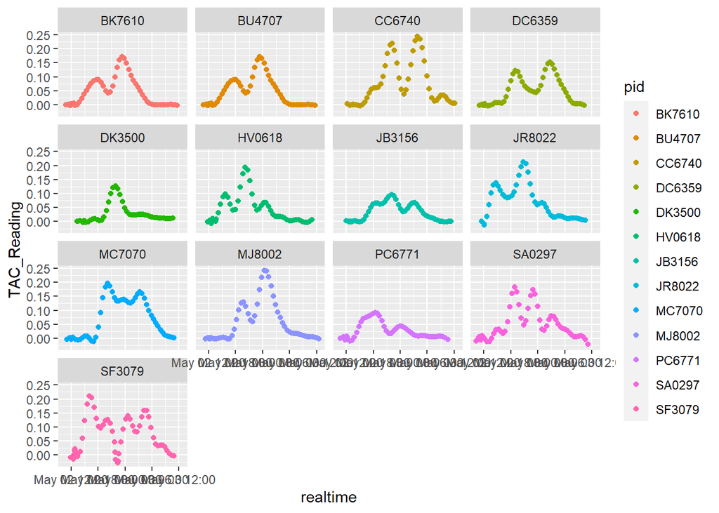

```r
tac_all %>% mutate(realtime=as.POSIXct(timestamp, origin="1970-01-01")) %>%
  mutate(pid=str_remove(id, "clean_tac/")) %>%
  mutate(pid=str_remove(pid, "_clean_TAC.csv")) %>%
  ggplot(aes(x=realtime, y=TAC_Reading, color=pid)) +
  facet_wrap(~pid, ncol=4) +
  geom_point()
```

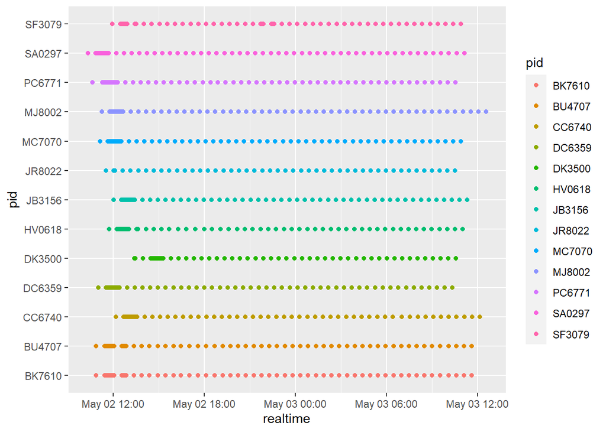

```r
tac_all %>% mutate(realtime=as.POSIXct(timestamp, origin="1970-01-01")) %>%
  mutate(pid=str_remove(id, "clean_tac/")) %>%
  mutate(pid=str_remove(pid, "_clean_TAC.csv")) %>%
  ggplot(aes(x=realtime, y=pid, color=pid)) +
  geom_point()
```

```r
tac_all_a <- tac_all %>%
  mutate(pid=str_remove(id, "clean_tac/")) %>%
  mutate(pid=str_remove(pid, "_clean_TAC.csv")) %>%
  mutate(time_30m=as.integer(timestamp/60/30)) %>%
  select(pid, timestamp, time_30m, TAC_Reading) %>%
  arrange(pid, timestamp)
tac_all_a
```

```
## # A tibble: 715 x 4
##    pid     timestamp time_30m TAC_Reading
##    <chr>       <dbl>    <int>       <dbl>
##  1 BK7610 1493718714   829843   -0.000482
##  2 BK7610 1493720697   829844    0.00157
##  3 BK7610 1493721027   829845    0.00214
##  4 BK7610 1493721357   829845    0.000877
##  5 BK7610 1493721686   829845   -0.00115
##  6 BK7610 1493722016   829845   -0.00216
##  7 BK7610 1493722345   829845   -0.00103
##  8 BK7610 1493722674   829845    0.00181
##  9 BK7610 1493723003   829846    0.00454
## 10 BK7610 1493724832   829847    0.00518
## # ... with 705 more rows
```

### combine

```r
data <- inner_join(tac_all_a, acc_a) %>%
  mutate(intox=(TAC_Reading > 0.08) * 1L)
data
```

```
## # A tibble: 11,155,752 x 9
##    pid     timestamp time_30m TAC_Reading       time     x       y       z intox
##    <chr>       <dbl>    <int>       <dbl>      <dbl> <dbl>   <dbl>   <dbl> <int>
##  1 BK7610 1493737046   829853      0.0654    1.49e12 0.126 -0.0078 -0.0243     0
##  2 BK7610 1493737046   829853      0.0654    1.49e12 0.134 -0.0697 -0.0446     0
##  3 BK7610 1493737046   829853      0.0654    1.49e12 0.144 -0.0474 -0.0447     0
##  4 BK7610 1493737046   829853      0.0654    1.49e12 0.126 -0.0038  0.0111     0
##  5 BK7610 1493737046   829853      0.0654    1.49e12 0.108  0.0032  0.0276     0
##  6 BK7610 1493737046   829853      0.0654    1.49e12 0.116 -0.0284  0          0
##  7 BK7610 1493737046   829853      0.0654    1.49e12 0.108 -0.0282 -0.0035     0
##  8 BK7610 1493737046   829853      0.0654    1.49e12 0.102 -0.0145 -0.0042     0
##  9 BK7610 1493737046   829853      0.0654    1.49e12 0.113  0.008  -0.0172     0
## 10 BK7610 1493737046   829853      0.0654    1.49e12 0.114  0.0097 -0.0038     0
## # ... with 11,155,742 more rows
```

### Generator

```r
generator <- function(data, lookback, delay, min_index, max_index,
                      shuffle = FALSE, batch_size = 16, step = 1) {
  if (is.null(max_index))
    max_index <- nrow(data) - delay
  i <- min_index + lookback
  function() {
    if (shuffle) {
      rows <- sample(c((min_index+lookback):max_index), size = batch_size)
    } else {
      if (i + batch_size >= max_index)
        i <<- min_index + lookback
      rows <- c(i:min(i+batch_size, max_index))
      i <<- i + length(rows)
    }

    samples <- array(0, dim = c(length(rows),
                                lookback / step,
                                3))
    targets <- array(0, dim = c(length(rows)))

    for (j in 1:length(rows)) {
      indices <- seq(rows[[j]] - lookback, rows[[j]],
                     length.out = dim(samples)[[2]])

            # make sure all from same person
      discord <- sum(data$pid[indices] != data$pid[rows[[j]]])
      if (discord > 0) {
        indices <- indices + discord
        rows[[j]] + discord
      }

      samples[j,,] <- as.matrix(data[round(indices),c("x", "y", "z")])
      targets[[j]] <- as.matrix(data[rows[[j]] + delay, "intox"])
    }

    list(samples, targets)
  }
}
```

```r
lookback <- 3600
step <- 4
delay <- 0
batch_size <- 16

train_gen <- generator(
  data = data,
  lookback = lookback,
  delay = delay,
  min_index = 1,
  max_index = {which(data$pid=="MC7070") %>% max()},
  shuffle = TRUE,
  step = step,
  batch_size = batch_size
)

val_gen = generator(
  data = data,
  lookback = lookback,
  delay = delay,
  min_index = {which(data$pid=="MC7070") %>% max() + 1},
  max_index = {which(data$pid=="PC6771") %>% max()},
  shuffle = TRUE,
  step = step,
  batch_size = batch_size
)

test_gen <- generator(
  data = data,
  lookback = lookback,
  delay = delay,
  min_index = {which(data$pid=="PC6771") %>% max() + 1},
  max_index = nrow(data),
  shuffle = TRUE,
  step = step,
  batch_size = batch_size
)

# This is how many steps to draw from `val_gen`
# in order to see the whole validation set:
val_steps <- ({which(data$pid=="MJ8002") %>% max()} - {which(data$pid=="MC7070") %>% max() + 1} - lookback) / batch_size
val_steps
```

```
## [1] 39231.38
```

```r
test_steps <- (nrow(data) - {which(data$pid=="PC6771") %>% max() + 1} - lookback) / batch_size
test_steps
```

```
## [1] 82769.75
```

```r
val_steps <- 1600/batch_size
val_steps
```

```
## [1] 100
```

```r
test_steps <- 1600/batch_size
test_steps
```

```
## [1] 100
```

### A basic machine learning approach

```r
set.seed(1)

model <- keras_model_sequential() %>%
  layer_flatten(input_shape = c(lookback / step, 3)) %>%
  layer_dense(units = 32, activation = "relu") %>%
  layer_dense(units = 1)

model %>% compile(
  optimizer = optimizer_rmsprop(),
  loss = "binary_crossentropy",
  metrics = "accuracy"
)

system.time(history <- model %>% fit(
  train_gen,
  steps_per_epoch = 100,
  epochs = 20,
  validation_data = val_gen,
  validation_steps = val_steps
))

model %>% evaluate(test_gen, steps=test_steps)
```

[output not shown]

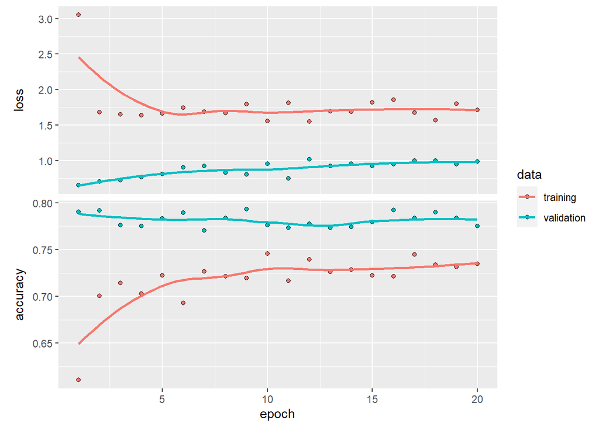

```r
plot(history)
```

## A first recurrent baseline

```r
model_r <- keras_model_sequential() %>%
  layer_gru(units = 16, input_shape = c(lookback / step, 3)) %>%
  layer_dense(units = 1)

model_r %>% compile(
  optimizer = optimizer_rmsprop(),
  loss = "binary_crossentropy",
  metrics = "accuracy"
)

system.time(history_r <- model_r %>% fit_generator(
  train_gen,
  steps_per_epoch = 100,
  epochs = 20,
  validation_data = val_gen,
  validation_steps = val_steps
))
```

```
##    user  system elapsed
## 3299.97  252.03 1696.11
```

```r
model_r %>% evaluate(test_gen, steps=test_steps)
```

```
##      loss  accuracy
## 0.8101153 0.4250000
```

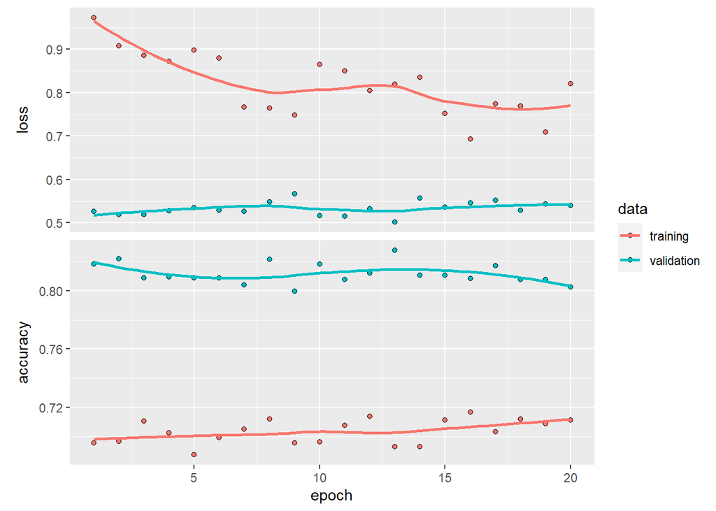

```r
plot(history_r)
```

## Using recurrent dropout to fight overfitting

```r
model_rd <- keras_model_sequential() %>%
  layer_gru(units = 16, dropout = 0.2, recurrent_dropout = 0.2,
            input_shape = c(lookback / step, 3)) %>%
  layer_dense(units = 1)

model_rd %>% compile(
  optimizer = optimizer_rmsprop(),
  loss = "binary_crossentropy",
  metrics = "accuracy"
)

system.time(history_rd <- model_rd %>% fit_generator(
  train_gen,
  steps_per_epoch = 100,
  epochs = 20,
  validation_data = val_gen,
  validation_steps = val_steps
))
```

```
##    user  system elapsed
## 5204.36  360.79 2145.48
```

```r
model_rd %>% evaluate(test_gen, steps=test_steps)
```

```
##      loss  accuracy
## 0.7815697 0.4181250
```

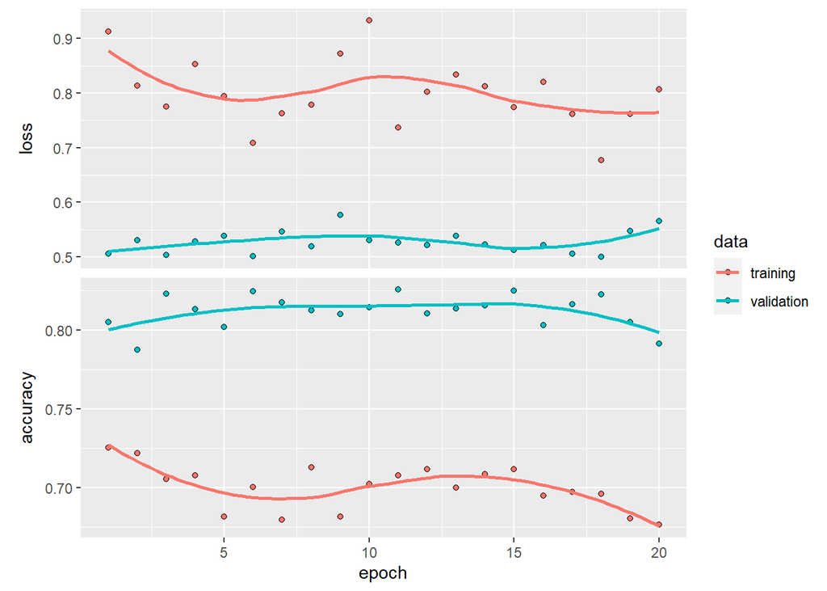

```r
plot(history_rd)
```

## Stacking recurrent layers

```r
model_sr <- keras_model_sequential() %>%
  layer_gru(units = 16,
            dropout = 0.1,
            recurrent_dropout = 0.5,
            return_sequences = TRUE,
            input_shape = c(lookback / step, 3)) %>%
  layer_gru(units = 16, activation = "relu",
            dropout = 0.1,
            recurrent_dropout = 0.5) %>%
  layer_dense(units = 1)

model_sr %>% compile(
  optimizer = optimizer_rmsprop(),
  loss = "binary_crossentropy",
  metrics = "accuracy"
)

system.time(history_sr <- model_sr %>% fit_generator(
  train_gen,
  steps_per_epoch = 100,
  epochs = 20,
  validation_data = val_gen,
  validation_steps = val_steps
))
```

```
##     user   system  elapsed
## 10525.92   629.39  3841.47
```

```r
model_sr %>% evaluate(test_gen, steps=test_steps)
```

```
##      loss  accuracy
## 0.7638409 0.4268750
```

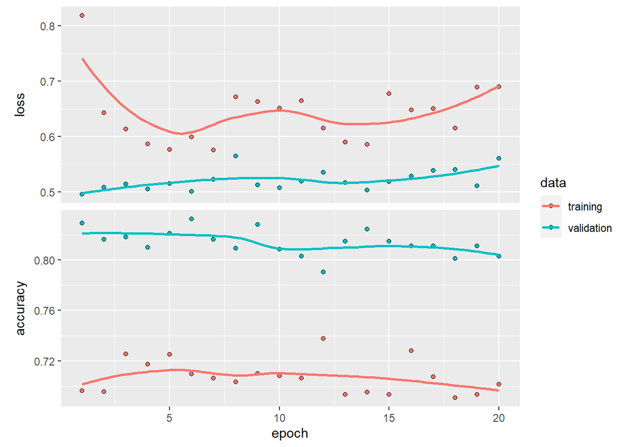

```r
plot(history_sr)
```

## Using bidirectional RNNs

```r
model_bR <- keras_model_sequential() %>%
  bidirectional(
    layer_gru(units = 16), input_shape = c(lookback / step, 3)
  ) %>%
  layer_dense(units = 1)

model_bR %>% compile(
  optimizer = optimizer_rmsprop(),
  loss = "binary_crossentropy",
  metrics = "accuracy"
)

system.time(history_bR <- model_bR %>% fit_generator(
  train_gen,
  steps_per_epoch = 100,
  epochs = 20,
  validation_data = val_gen,
  validation_steps = val_steps
))
```

```
##    user  system elapsed
## 5835.24  320.29 2304.29
```

```r
model_bR %>% evaluate(test_gen, steps=test_steps)
```

```
##      loss  accuracy
## 0.7897041 0.4243750
```

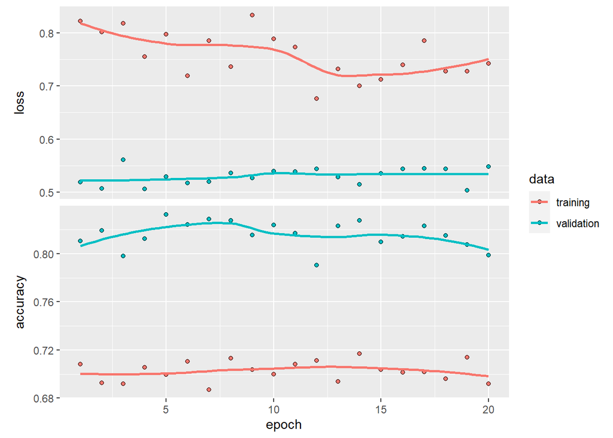

```r
plot(history_bR)
```

## Combining CNNs and RNNs to process long sequences

```r
model_C <- keras_model_sequential() %>%
  layer_conv_1d(filters = 16, kernel_size = 5, activation = "relu",
                input_shape = c(lookback / step, 3)) %>%
  layer_max_pooling_1d(pool_size = 3) %>%
  layer_conv_1d(filters = 16, kernel_size = 5, activation = "relu") %>%
  layer_max_pooling_1d(pool_size = 3) %>%
  layer_conv_1d(filters = 16, kernel_size = 5, activation = "relu") %>%
  layer_global_max_pooling_1d() %>%
  layer_dense(units = 1)


model_C %>% compile(
  optimizer = optimizer_rmsprop(),
  loss = "binary_crossentropy",
  metrics = "acc"
)

system.time(history_C <- model_C %>% fit_generator(
  train_gen,
  steps_per_epoch = 100,
  epochs = 20,
  validation_data = val_gen,
  validation_steps = val_steps
))
```

```
##    user  system elapsed
## 1149.53  186.63  739.03
```

```r
model_C %>% evaluate(test_gen, steps=test_steps)
```

```
##      loss       acc
## 0.6075781 0.6393750
```

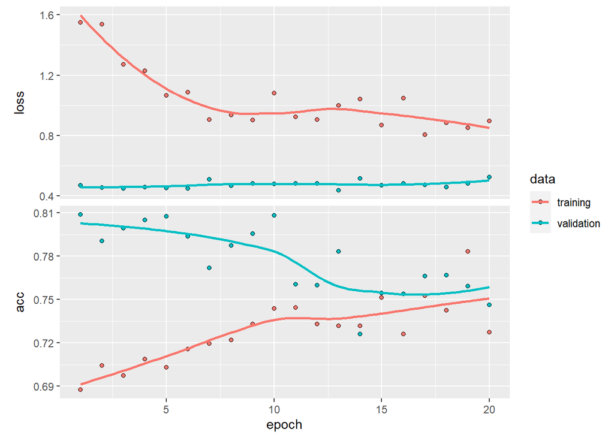

```r
plot(history_C)
```

This is the model, starting with two `layer_conv_1d()` and following up with a `layer_gru()`:

```r
model_CR <- keras_model_sequential() %>%
  layer_conv_1d(filters = 16, kernel_size = 5, activation = "relu",
                input_shape = c(lookback / step, 3)) %>%
  layer_max_pooling_1d(pool_size = 3) %>%
  layer_conv_1d(filters = 16, kernel_size = 5, activation = "relu") %>%
  layer_gru(units = 16, dropout = 0.1, recurrent_dropout = 0.5) %>%
  layer_dense(units = 1)

summary(model_CR)
```

```
## Model: "sequential_6"
## ________________________________________________________________________________
## Layer (type)                        Output Shape                    Param #
## ================================================================================
## conv1d_4 (Conv1D)                   (None, 896, 16)                 256
## ________________________________________________________________________________
## max_pooling1d_2 (MaxPooling1D)      (None, 298, 16)                 0
## ________________________________________________________________________________
## conv1d_3 (Conv1D)                   (None, 294, 16)                 1296
## ________________________________________________________________________________
## gru_5 (GRU)                         (None, 16)                      1584
## ________________________________________________________________________________
## dense_7 (Dense)                     (None, 1)                       17
## ================================================================================
## Total params: 3,153
## Trainable params: 3,153
## Non-trainable params: 0
## ________________________________________________________________________________
```

```r
model_CR %>% compile(
  optimizer = optimizer_rmsprop(),
  loss = "binary_crossentropy",
  metrics = "acc"
)

system.time(history_CR <- model_CR %>% fit_generator(
  train_gen,
  steps_per_epoch = 100,
  epochs = 20,
  validation_data = val_gen,
  validation_steps = val_steps
))
```

```
##    user  system elapsed
## 2789.05  283.69 1278.83
```

```r
model_CR %>% evaluate(test_gen, steps=test_steps)
```

```
##      loss       acc
## 0.6030378 0.6956250
```

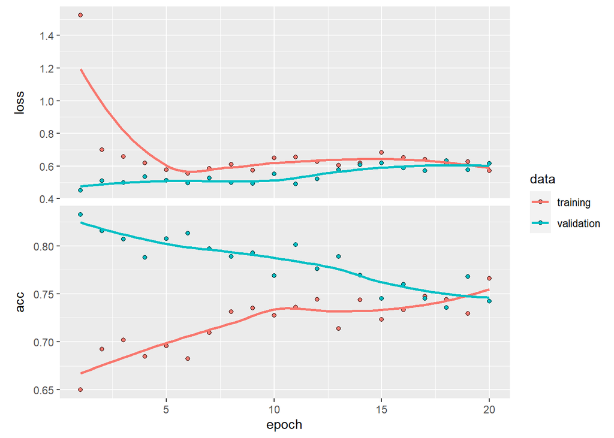

```r
plot(history_CR)
```